# Problem Set 4, Solutions

Stats 506, F19

November 30, 2019

```r
# libraries
library(tidyverse)
```

## About

This assignment asked you to perform various analyses in Stata. Those analyses can be found in the problem sets folder of the course [repo](https://github.com/jbhender/Stats506_F19/tree/master/problem_sets).

In the solutions below, we read in the results output by the Stata scripts and provide substantive answers to the questions posed.

## Question 1

See `ps4_q1.do` for the analysis in which we fit linear mixed models comparing the log curvature measures between the typical and atypical conditions from the mouse-tracking experiments of problem set 2.

The code below reads the results into R.

```r
# Results for each measure are in their own sheets
measures = c('tot_dist', 'max_abs_dev', 'avg_abs_dev', 'auc')
sheets = paste('log', measures, sep = '_')
clean_measures = c('Total Distance',
                   'Max Abs Deviation',
                   'Avg Abs Deviation',
                   'AUC')
names(clean_measures) = measures

# Read and combine all measures
result_list = vector(mode = 'list', length = length(sheets))
names(result_list) = sheets
for (sheet in sheets) {
 result_list[[sheet]] =   readxl::read_xlsx("./ps4_q1_results.xlsx", sheet = sheet)
}

results_df = bind_rows(result_list)
```

Next, we clean the results.

```r
# atypical coefficients (multiplier)
atypical_df = results_df %>%
  filter( term == '1.condition_atypical') %>%
  transmute(
    measure = str_replace_all(group, 'log_', ''),
    term = 'atypical',
    est = exp(est),
    lwr = exp(lwr),
    upr = exp(upr)
  )

# baseline intercepts from typical condtion
typical_df = results_df %>%
  filter( term == '_cons' & grepl('^log', group)) %>%
  transmute(
    measure = str_replace_all(group, 'log_', ''),
    term = 'typical',
    est = exp(est),
    lwr = exp(lwr),
    upr = exp(upr)
  )

# random effect standard deviations
# For the variances as repored by Stata, square these results.
ranef_df = results_df %>%
  filter( term == '_cons' & grepl('^lns', group)) %>%
  transmute(
    measure = rep(typical_df$measure, each = 3),
    term = rep( c('subject', 'exemplar', 'error'), 4),
    est = exp(est),
    lwr = exp(lwr),
    upr = exp(upr)
  )
```

Now we plot the results.

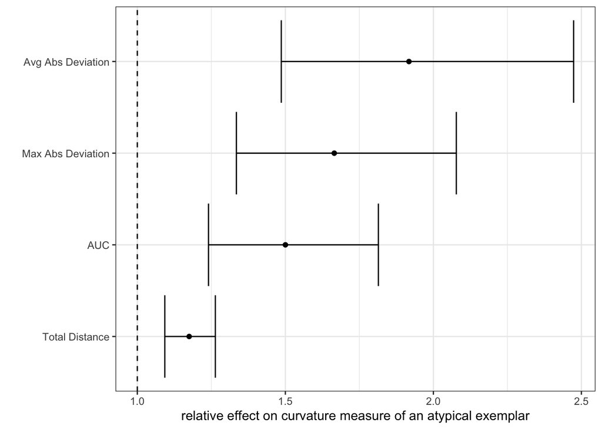

**Figure 1.** *Relative effect of atypical condition on each curvature measure.*

```r
cap = paste(
  "**Figure 1.** *Relative effect of atypical condition on each curvature measure.*")

atypical_df %>%
  arrange( est ) %>%
  mutate( measure = factor(measure, levels = unique(measure),
                           labels = clean_measures[unique(measure)]) ) %>%
  ggplot( aes( y = measure, x = est) ) +
  geom_point() +
  geom_errorbarh( aes(xmin = lwr, xmax = upr) ) +
  geom_vline( xintercept = 1, lty = 'dashed') +
  xlab('relative effect on curvature measure of an atypical exemplar') +
  ylab('') +
  theme_bw()
```

Finally, this table summarizes all four models. Note that the variance terms for the random effects are given here on the standard deviation scale.

```r
cap = paste(
  '**Table 1.** *Coefficients for linear mixed models of log curvature',
  'measure with an indicator for the atypical conditions as the covariate and',
  'variance effects (on the standard deviation scale) for subject and',
  'exemplar Values are shown as estimates',
  '(on the natural scale) and (Wald) 95% confidence intervals.*'
)
bind_rows( typical_df, atypical_df, ranef_df) %>%
  mutate( ci = sprintf('%.2f (%.2f, %.2f)', est, lwr, upr)) %>%
  pivot_wider(id_cols = term, names_from = measure, values_from = ci) %>%
  knitr::kable(format = 'html', caption = cap,
              col.names = c('Model term', clean_measures) ) %>%
  kableExtra::kable_styling("striped", full_width = TRUE)
```

**Table 1.** *Coefficients for linear mixed models of log curvature measure with an indicator for the atypical conditions as the covariate and variance effects (on the standard deviation scale) for subject and exemplar Values are shown as estimates (on the natural scale) and (Wald) 95% confidence intervals.*

| Model term | Total Distance | Max Abs Deviation | Avg Abs Deviation | AUC |
| --- | --- | --- | --- | --- |
| typical | 1276.18 (1217.57, 1337.61) | 117.63 (100.90, 137.13) | 21.80 (18.04, 26.34) | 60786.31 (52858.34, 69903.36) |
| atypical | 1.18 (1.09, 1.26) | 1.67 (1.33, 2.08) | 1.92 (1.49, 2.47) | 1.50 (1.24, 1.81) |
| subject | 0.09 (0.07, 0.13) | 0.36 (0.28, 0.47) | 0.50 (0.39, 0.63) | 0.36 (0.28, 0.47) |
| exemplar | 0.06 (0.04, 0.10) | 0.18 (0.10, 0.30) | 0.20 (0.11, 0.35) | 0.13 (0.07, 0.27) |
| error | 0.31 (0.29, 0.32) | 1.07 (1.03, 1.12) | 1.25 (1.20, 1.31) | 1.06 (1.01, 1.11) |

## Question 2

In this question, we use Stata and the RECS 2015 data to compare disparities in internet access betwen urban (including “urban cluster”) and rural areas. The bulk of the analysis appears in `ps4_q2.do`.

First we read and clean the data.

```r
# clean data from older questions
rm( list = ls() )

# read in q2 results
q2_df = readr::read_delim("./ps4_q2_results.csv", delim = ",")
```

Next, we plot the proportion of homes with internet access in the urban and rural areas of each census division.

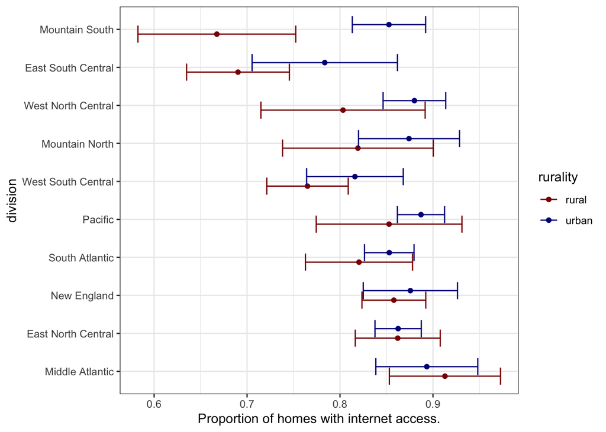

**Figure 2.** *Proportion of homes with internet access in each Census Division.*

```r
cap = paste("**Figure 2.** *Proportion of homes with internet access in each",
            "Census Division.*")

# reshape for plotting
plot_data = q2_df %>%
  pivot_longer(cols = starts_with('p_int'), names_prefix = 'p_int',
               names_to = 'var') %>%
  mutate( rurality = stringr::str_replace_all(var, '_.*', ''),
          type = ifelse( grepl('_', var),
                        stringr::str_replace_all(var, '.*_', ''),
                        'est'
                        )
  ) %>%
  pivot_wider(id_cols = c('division', 'rurality'),
              names_from = type,
              values_from = value
  )

# order divisions by urban rural differences
div_order =
  {plot_data %>%
  filter(rurality == 'diff' ) %>%
  arrange( est )}$division

plot_data = mutate(plot_data, division = factor(division, div_order))

# plot
plot_data %>%
  filter( rurality != 'diff' ) %>%
  ggplot( aes( x = division, color = rurality ) ) +
  geom_point( aes(y = est), position = position_dodge(width = 0.5) ) +
  geom_errorbar( aes(ymin = lwr, ymax = upr),
                  position = position_dodge(width = 0.5) ) +
  theme_bw() +
  scale_color_manual( values = c("darkred", "darkblue")) +
  ylab("Proportion of homes with internet access.") +
  coord_flip()
```

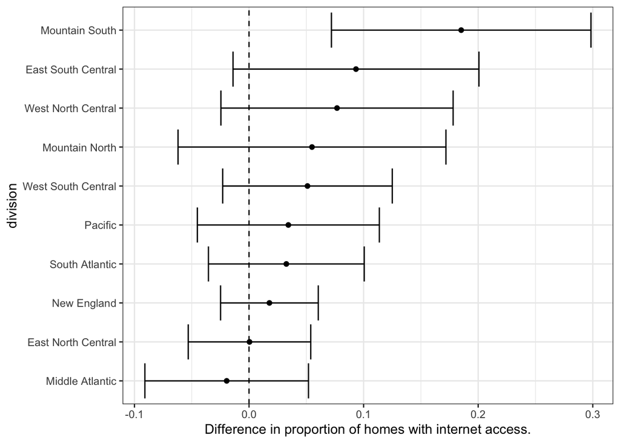

**Figure 3.** *Difference (urban less rural) in proportion of homes with internet access in each Census Division.*

```r
cap = paste("**Figure 3.** *Difference (urban less rural) in proportion of",
  "homes with internet access in each Census Division.*")

plot_data %>%
  filter( rurality == 'diff' ) %>%
  ggplot( aes( x = division)  ) +
  geom_point( aes(y = est) ) +
  geom_errorbar( aes(ymin = lwr, ymax = upr) ) +
  theme_bw() +
  scale_color_manual( values = c("darkred", "darkblue")) +
  ylab("Difference in proportion of homes with internet access.") +
  geom_hline(yintercept = 0, lty = 'dashed') +
  coord_flip()
```

## Question 3

In this problem, we use 2005-2006 NHANES data to answer the question:

> Are people in the US more likely to drink water on a weekday than a weekend day?

The data preparation and analyses addressing this question are in `ps4_q3.do`.

Next, we read in the coefficients and marginal effects from part (c) and (d) and present each in a table.

```r
sheets = c('logit_coef', 'logit_me',
           'mixed_logit_coef', 'mixed_logit_me')

results_list = vector(mode = 'list', length = length(sheets) )
names(results_list) = sheets
for ( sheet in sheets ) {
  results_list[[sheet]] = readxl::read_xlsx('ps4_q3_results.xlsx', sheet = sheet)
}
```

Here we prepare the coefficient table.

```r
## Merge and clean coefficients for display
day1 = results_list[['logit_coef']] %>%
  transmute(group, term,
        day1 = sprintf('%4.2f (%4.2f, %4.2f)', exp(est), exp(lwr), exp(upr))
  )

day_both = results_list[['mixed_logit_coef']] %>%
  transmute(group, term,
            mixed = ifelse(group == 'any_water',
             sprintf('%4.2f (%4.2f, %4.2f)', exp(est), exp(lwr), exp(upr)),
             sprintf('%4.1f (%4.1f, %4.1f)', est, lwr, upr)
            )
  )

# clean names for coefficients
term_names = c(
  "1.weekday" = 'Weekday',
  "1.winter"  = 'Winter',
  "age_c" = 'Age',
  "c.age_c#c.age_c" = 'Age Squared',
  "2.gender" = 'Female',
  "pir_c" = 'Poverty Income Ratio',
  "_cons" = 'Baseline Odds',
  "var(_cons[seqn])" = "Var. of subject effects")

# Merge and clean
coef_tab = left_join(day_both, day1, by = c('group', 'term')) %>%
  filter( !grepl('b\\.', term)) %>%
  select(-group) %>%
  mutate(term = term_names[term] )
```

This is the coefficient table.

```r
cap = paste("**Table 2.** *Odds ratios for water drinking.*",
"Baseline odds are for a weekend day in the summer for a male", "respondent at mean age (27.3 years) and PIR (2.38). Note that age",
"is scaled in decades and has been centered."
)

knitr::kable(coef_tab, format = 'html', caption = cap) %>%
  kableExtra::kable_styling("striped", full_width = TRUE)
```

**Table 2.** *Odds ratios for water drinking.* Baseline odds are for a weekend day in the summer for a male respondent at mean age (27.3 years) and PIR (2.38). Note that age is scaled in decades and has been centered.

| term | mixed | day1 |
| --- | --- | --- |
| Weekday | 1.24 (1.11, 1.39) | 1.13 (1.03, 1.24) |
| Winter | 0.93 (0.81, 1.07) | 0.90 (0.82, 0.99) |
| Age | 1.36 (1.31, 1.42) | 1.16 (1.13, 1.19) |
| Age Squared | 0.96 (0.94, 0.97) | 0.97 (0.96, 0.98) |
| Female | 1.76 (1.53, 2.02) | 1.33 (1.21, 1.46) |
| Poverty Income Ratio | 1.18 (1.13, 1.23) | 1.09 (1.06, 1.13) |
| Baseline Odds | 5.55 (4.65, 6.63) | 2.59 (2.32, 2.90) |
| Var. of subject effects | 5.6 ( 4.9, 6.3) | NA |

Next, we prepare the table of average marginal effects.

```r
## Merge and clean marginal effects for display
day1_me = results_list[['logit_me']] %>%
  transmute(variable, day1 = sprintf('%5.3f (%5.3f, %5.3f)', est, lwr, upr) )

day_both_me = results_list[['mixed_logit_me']] %>%
  transmute(variable, mixed = sprintf('%5.3f (%5.3f, %5.3f)', est, lwr, upr) )

# clean names for coefficients
var_names = c(
  "1.weekday" = 'Weekday',
  "1.winter"  = 'Winter',
  "age_c" = 'Age',
  "c.age_c#c.age_c" = 'Age Squared',
  "2.gender" = 'Female',
  "pir_c" = 'Poverty Income Ratio'
)

# Merge and clean
me_tab = left_join(day_both_me, day1_me, by = 'variable') %>%
  filter( !grepl('b\\.', variable)) %>%
  mutate(variable = var_names[variable] )
```

Here is the table of average marginal effects.

```r
cap = paste("**Table 4.** *Average marginal effects for water drinking.*")

knitr::kable(me_tab, format = 'html', caption = cap) %>%
 kableExtra::kable_styling("striped", full_width = TRUE)
```

**Table 4.** *Average marginal effects for water drinking.*

| variable | mixed | day1 |
| --- | --- | --- |
| Weekday | 0.023 (0.011, 0.035) | 0.024 (0.005, 0.043) |
| Winter | -0.008 (-0.023, 0.007) | -0.020 (-0.039, -0.002) |
| Age | 0.036 (0.031, 0.041) | 0.032 (0.026, 0.038) |
| Female | 0.061 (0.046, 0.076) | 0.056 (0.038, 0.075) |
| Poverty Income Ratio | 0.018 (0.013, 0.023) | 0.018 (0.012, 0.024) |

The two models give very similar results, and both support the assertion that people are slightly more likely to drink water on a weekday than on the weekend.